# Reproducible Research: Peer Assessment 1

## Loading and preprocessing the data

This first thing to be done is to properly load the data. To accomplish that, we first unzip the file to then load it in R with the `read.csv` function.

```r
unzip("activity.zip")
grep("csv", list.files(), value = TRUE)
```

```
## [1] "activity.csv"
```

```r
activity <- read.csv("activity.csv")
dim(activity)
```

```
## [1] 17568     3
```

```r
head(activity)
```

```
##   steps       date interval
## 1    NA 2012-10-01        0
## 2    NA 2012-10-01        5
## 3    NA 2012-10-01       10
## 4    NA 2012-10-01       15
## 5    NA 2012-10-01       20
## 6    NA 2012-10-01       25
```

## What is mean total number of steps taken per day?

In order to find the mean total number of steps per day, we can use the tapply in together with the aggregate function.

```r
total_steps <- aggregate(steps ~ date, activity, function(s) sum(s, na.rm = TRUE))
total_steps
```

```
##          date steps
## 1  2012-10-02   126
## 2  2012-10-03 11352
## 3  2012-10-04 12116
## 4  2012-10-05 13294
## 5  2012-10-06 15420
## 6  2012-10-07 11015
## 7  2012-10-09 12811
## 8  2012-10-10  9900
## 9  2012-10-11 10304
## 10 2012-10-12 17382
## 11 2012-10-13 12426
## 12 2012-10-14 15098
## 13 2012-10-15 10139
## 14 2012-10-16 15084
```

[output cut: 39 more lines]

The histogram can be calculated with the `hist` function.

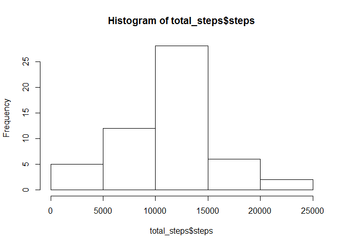

```r
hist(total_steps$steps)
```

Finally, we compute the mean and the median of the total number of steps.

```r
mean(total_steps$steps)
```

```
## [1] 10766.19
```

```r
median(total_steps$steps)
```

```
## [1] 10765
```

## What is the average daily activity pattern?

We find out the average with the `mean` function. In order to separate by 5-minute interval, we put together the `aggregate` function.

```r
mean_intervals <- aggregate(steps ~ interval, activity, mean)
mean_intervals
```

```
##     interval       steps
## 1          0   1.7169811
## 2          5   0.3396226
## 3         10   0.1320755
## 4         15   0.1509434
## 5         20   0.0754717
## 6         25   2.0943396
## 7         30   0.5283019
## 8         35   0.8679245
## 9         40   0.0000000
## 10        45   1.4716981
## 11        50   0.3018868
## 12        55   0.1320755
## 13       100   0.3207547
## 14       105   0.6792453
```

[output cut: 274 more lines]

We then plot the time interval agains the average number of steps.

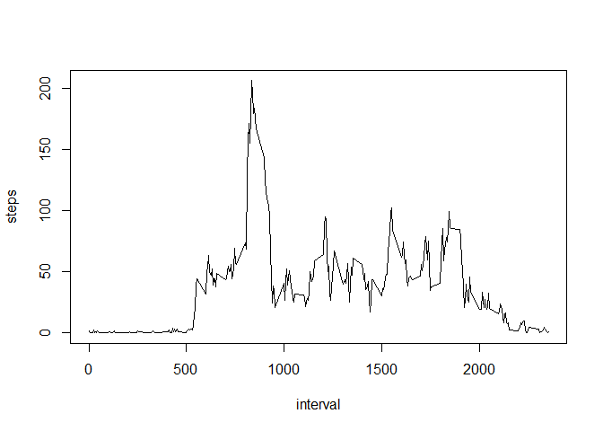

```r
with(mean_intervals, plot(interval, steps, type = "l"))
```

The interval which contains the peak can be found with the `max` function.

```r
with(mean_intervals, interval[steps == max(steps)])
```

```
## [1] 835
```

## Imputing missing values

In order to calculate the total number of missing values, we could use the `table` function.

```r
with(activity, table(is.na(steps)))["TRUE"]
```

```
## TRUE
## 2304
```

In order to impute the missing values, the means for the interval will be used.

```r
impute_activity <- activity
missing <- is.na(impute_activity$steps)
key_mean_intervals <- mean_intervals$steps
names(key_mean_intervals) <- mean_intervals$interval
impute_activity$steps[missing] <- key_mean_intervals[as.character(impute_activity$interval[missing])]
```

Now we analyze the total steps in the impute table.

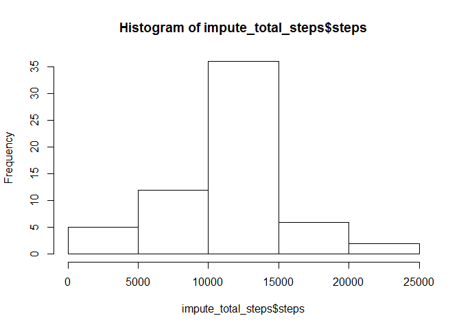

```r
impute_total_steps <- aggregate(steps ~ date, impute_activity, function(s) sum(s, na.rm = TRUE))
hist(impute_total_steps$steps)
```

```r
mean(impute_total_steps$steps)
```

```
## [1] 10766.19
```

```r
median(impute_total_steps$steps)
```

```
## [1] 10766.19
```

We can see that, with the imputed missing values, the mean is the same whereas the median is now equal to the mean. This can be explained because now there are a lot more points which drag the median of the data towards the mean.

## Are there differences in activity patterns between weekdays and weekends?

We now wish the compare the differences between activity in a weekday versus a weekend.

```r
Sys.setlocale("LC_TIME", "English") # sets English locale
```

```
## [1] "English_United States.1252"
```

```r
days_of_week <- weekdays(as.Date(activity$date))
unique(days_of_week)
```

```
## [1] "Monday"    "Tuesday"   "Wednesday" "Thursday"  "Friday"    "Saturday"
## [7] "Sunday"
```

```r
weekday_category <- as.factor(ifelse(days_of_week %in% c("Saturday", "Sunday"), "weekend", "weekday"))
activity$category <- weekday_category
```

We now compare the averaged steps for weekday (black) versus weekend (red) in the graph.

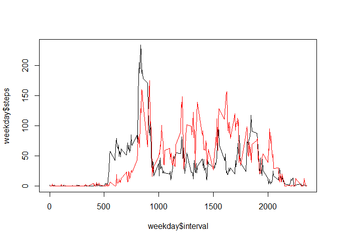

```r
weekday_intervals <- aggregate(steps ~ interval + category, activity, function(s) mean(s, na.rm = T))
weekday <- subset(weekday_intervals, category == "weekday", select = c("interval", "steps"))
weekend <- subset(weekday_intervals, category == "weekend", select = c("interval", "steps"))
plot(weekday$interval, weekday$steps, type = "l")
lines(weekend$interval, weekend$steps, col = "red")
```